# Much Ado About Nothing

Rhys Maredudd Davies

09 November, 2023

# Eeeeeeek! MICE!! (Multiple Imputed Chained Equations)

Welcome back. Last week we focused on methods of identifying and understanding our missing data, as well as visualising the effects of various imputation strategies. We were also briefly introduced to one of the recommended approaches of imputing our missing data, through using multiple imputation strategies.

Now unfortunately, the examples of last week were only a rough version - quick and dirty to get the job done and to help us visualise different aspects of missing data and quickly dealing with it. Today we will be going through a MICE workflow in greater detail, so that we can apply it to best. We also demonstrate how we can edit and manipulate MICE so that it can accurately and effectively work with our data

Disclaimer - this is going to involve some theory work again…

For anyone who wants to read further about this method, and have access to a detailed workflow, then please check out this excellent e-book from Steffan Van Buuren (https://stefvanbuuren.name/fimd/workflow.html).

(I did use that workflow as a guide for today)

Aims for today:

- Learn to use MICE to impute missing data.
  - Learn how to manipulate MICE so that it can identify the best imputation strategy for each column of our missing data.
- Learn how to pool our multiple imputed data files.
  - Learn how to use this pooled data for analysis.
- Learn to visualise our pooled data so that we can evaluate it.

Lets get going shall we?

## Understanding our data

This will be a quick but essential revisit of last week. Our aim here is to understand our missing data, so that we can determine where our missing data is, and what type of missing data is it.

The dataset we will be working with today is the `nhanes2` dataset from the `mice` package - This is a small data set which is used to examine how cholesterol, age and bmi influence hypertension. (We are working with `nhanes2` instead of `nhanes` as it contains missing data in both the numeric and categorical measures - this is to demonstrate that we can do both with mice!)

```r
?nhanes
```

```
## starting httpd help server ... done
```

```r
summary(nhanes2)
```

```
##     age          bmi          hyp          chl
##  20-39:12   Min.   :20.40   no  :13   Min.   :113.0
##  40-59: 7   1st Qu.:22.65   yes : 4   1st Qu.:185.0
##  60-99: 6   Median :26.75   NA's: 8   Median :187.0
##             Mean   :26.56             Mean   :191.4
##             3rd Qu.:28.93             3rd Qu.:212.0
##             Max.   :35.30             Max.   :284.0
##             NA's   :9                 NA's   :10
```

```r
str(nhanes2)
```

```
## 'data.frame':    25 obs. of  4 variables:
##  $ age: Factor w/ 3 levels "20-39","40-59",..: 1 2 1 3 1 3 1 1 2 2 ...
##  $ bmi: num  NA 22.7 NA NA 20.4 NA 22.5 30.1 22 NA ...
##  $ hyp: Factor w/ 2 levels "no","yes": NA 1 1 NA 1 NA 1 1 1 NA ...
##  $ chl: num  NA 187 187 NA 113 184 118 187 238 NA ...
```

```r
# Transforming nhanes2 to faciliate mice

nhanes3 <- nhanes2 %>% mutate(
  hyp = as.factor(case_when(hyp == "no" ~ "0",
                  hyp == "yes" ~ "1")))


summary(nhanes3)
```

```
##     age          bmi          hyp          chl
##  20-39:12   Min.   :20.40   0   :13   Min.   :113.0
##  40-59: 7   1st Qu.:22.65   1   : 4   1st Qu.:185.0
##  60-99: 6   Median :26.75   NA's: 8   Median :187.0
##             Mean   :26.56             Mean   :191.4
##             3rd Qu.:28.93             3rd Qu.:212.0
##             Max.   :35.30             Max.   :284.0
##             NA's   :9                 NA's   :10
```

So in our summary we see that we have `9` NA in `bmi`, `8` NA in `hyp`, and `10` NA in `chl`. Now let us run our missing data summaries to get more details on how much is missing where in our data:

```r
## Summaries for missing data across data
n_miss(nhanes3) # provides total number of missing datum's across data
```

```
## [1] 27
```

```r
n_complete(nhanes3) # Provides total number of complete datum's across data
```

```
## [1] 73
```

```r
pct_miss(nhanes3) # Provides the percentage of missing data - very useful for reporting.
```

```
## [1] 27
```

```r
pct_complete(nhanes3) # Provides the percentage of complete data.
```

```
## [1] 73
```

```r
## Summaries of missing data across variables and cases
miss_var_summary(nhanes3) # A summary of n missing and % missing across each variables
```

```
## # A tibble: 4 × 3
##   variable n_miss pct_miss
##   <chr>     <int>    <dbl>
## 1 chl          10       40
## 2 bmi           9       36
## 3 hyp           8       32
## 4 age           0        0
```

```r
miss_var_table(nhanes3) # A generalised summary of n missing per variable, with associated %.
```

```
## # A tibble: 4 × 3
##   n_miss_in_var n_vars pct_vars
##           <int>  <int>    <dbl>
## 1             0      1       25
## 2             8      1       25
## 3             9      1       25
## 4            10      1       25
```

```r
miss_case_summary(nhanes3) # A case by case summary of n missing and % missing. Very useful for survey data if you need to remove participant who barely attempted completion.
```

```
## # A tibble: 25 × 3
##     case n_miss pct_miss
##    <int>  <int>    <dbl>
##  1     1      3       75
##  2     4      3       75
##  3    10      3       75
##  4    11      3       75
##  5    12      3       75
##  6    16      3       75
##  7    21      3       75
##  8     6      2       50
##  9     3      1       25
## 10    15      1       25
## # ℹ 15 more rows
```

```r
miss_case_table(nhanes3) # A generalised summary of n missing per case, with associated %
```

```
## # A tibble: 4 × 3
##   n_miss_in_case n_cases pct_cases
##            <int>   <int>     <dbl>
## 1              0      13        52
## 2              1       4        16
## 3              2       1         4
## 4              3       7        28
```

So to report - the `nhanes3` data had `27%` of it’s entries missing. Across the variables, `chl` had `10` missing entries ( *40%*), `bmi` had `9` missing entries ( *36%*), `hyp` had `8` missing entries ( *32%*), and age had `0` missing entries. On a case wise summary, *52%* had 0 missing entries, *16%* had 1 missing entry, *4%* had 2 missing entries, and *28%* had 3 missing entries.

Now that we understand the descriptives of our missing data, it’s time to identify the categorisation of the missing data. We will do this statistically, and visually.

First off - the Little (1988) MCAR test to determine if data is MCAR (or potentially MNAR), or MAR (or also potentially MNAR…).

```r
mcar_test(nhanes3)
```

```
## # A tibble: 1 × 4
##   statistic    df p.value missing.patterns
##       <dbl> <dbl>   <dbl>            <int>
## 1      8.00     9   0.534                5
```

Now to visually inspect to help us understand if the data is MCAR or MNAR.

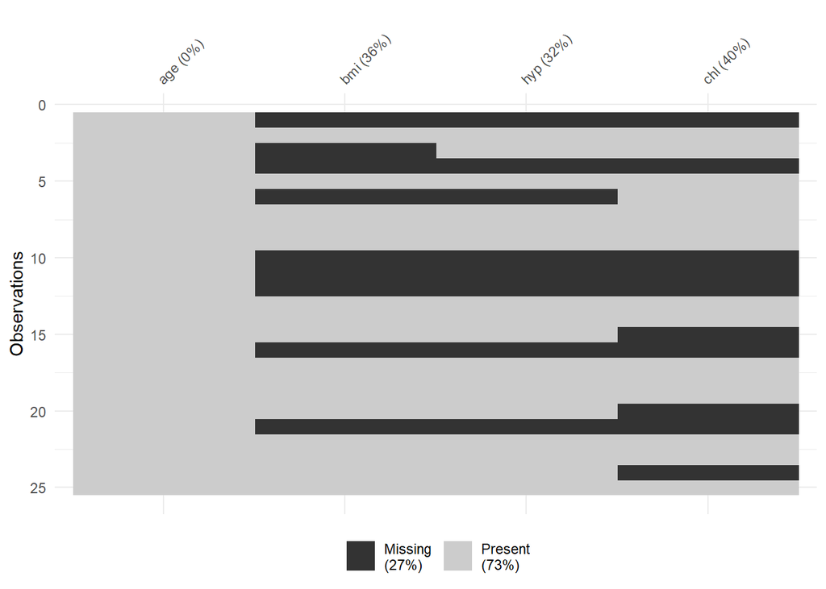

```r
vis_miss(nhanes3)
```

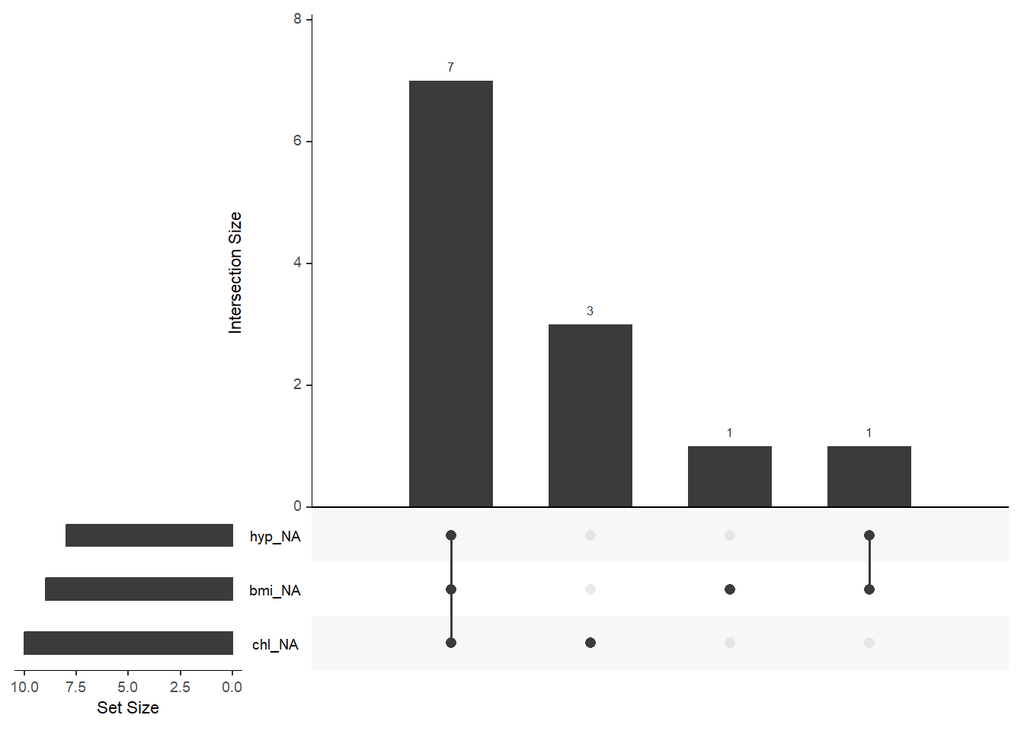

```r
gg_miss_upset(nhanes3)
```

Just to be safe, we will check if the missing data is in any way associated with age.

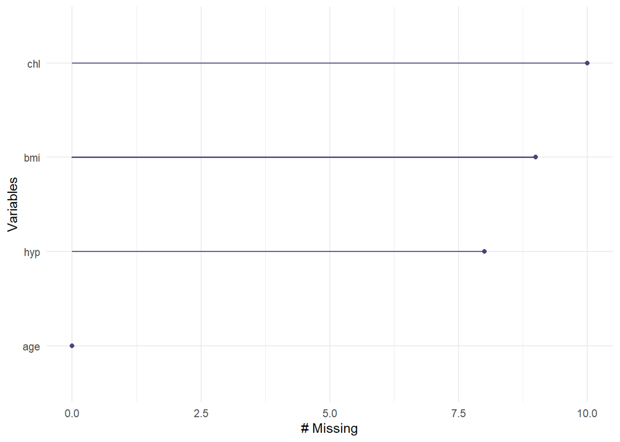

```r
gg_miss_var(nhanes3)
```

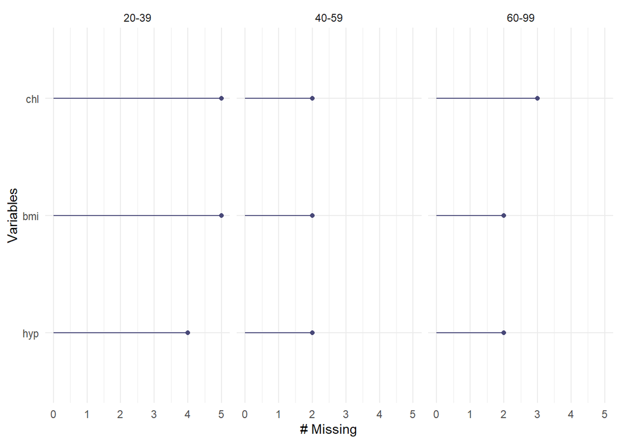

```r
gg_miss_var(nhanes3,
            facet = age)
```

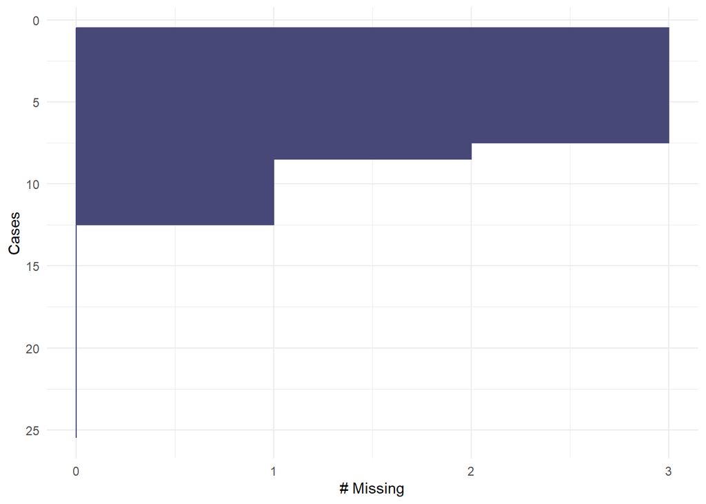

```r
gg_miss_case(nhanes3)
```

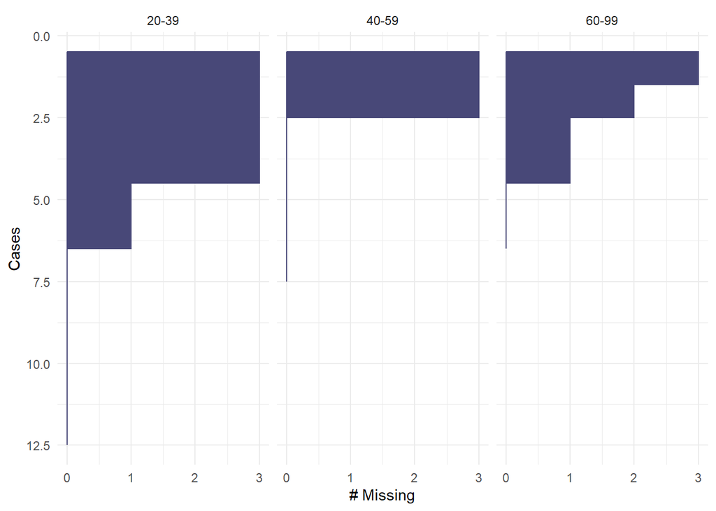

```r
gg_miss_case(nhanes3,
            facet = age)
```

The younger group appears to have a higher concentration of missing data, but it does not look to be substantially greater proportion wise. But to be safe, we can test with logistic regression and the `geom_shadow()` function.

```r
nhanes_shadow <- nhanes3 %>% bind_shadow()

model_bmi <- glm(bmi_NA ~ 0+ age, family="binomial", data = nhanes_shadow )

summary(model_bmi) # No sig difference between age group and BMI missing data
```

```
##
## Call:
## glm(formula = bmi_NA ~ 0 + age, family = "binomial", data = nhanes_shadow)
##
## Coefficients:
##          Estimate Std. Error z value Pr(>|z|)
## age20-39  -0.3365     0.5855  -0.575    0.566
## age40-59  -0.9163     0.8367  -1.095    0.273
## age60-99  -0.6931     0.8660  -0.800    0.423
##
## (Dispersion parameter for binomial family taken to be 1)
##
##     Null deviance: 34.657  on 25  degrees of freedom
## Residual deviance: 32.315  on 22  degrees of freedom
## AIC: 38.315
##
## Number of Fisher Scoring iterations: 4
```

```r
model_hyp <- glm(hyp_NA ~ 0+ age, family="binomial", data = nhanes_shadow )

summary(model_hyp) # No sig difference between age group and hyp missing data
```

```
##
## Call:
## glm(formula = hyp_NA ~ 0 + age, family = "binomial", data = nhanes_shadow)
##
## Coefficients:
##          Estimate Std. Error z value Pr(>|z|)
## age20-39  -0.6931     0.6124  -1.132    0.258
## age40-59  -0.9163     0.8367  -1.095    0.273
## age60-99  -0.6931     0.8660  -0.800    0.423
##
## (Dispersion parameter for binomial family taken to be 1)
##
##     Null deviance: 34.657  on 25  degrees of freedom
## Residual deviance: 31.290  on 22  degrees of freedom
## AIC: 37.29
##
## Number of Fisher Scoring iterations: 4
```

```r
model_chl <- glm(chl_NA ~ 0+ age, family="binomial", data = nhanes_shadow )

summary(model_chl) # No sig difference between age group and chl missing data
```

```
##
## Call:
## glm(formula = chl_NA ~ 0 + age, family = "binomial", data = nhanes_shadow)
##
## Coefficients:
##            Estimate Std. Error z value Pr(>|z|)
## age20-39 -3.365e-01  5.855e-01  -0.575    0.566
## age40-59 -9.163e-01  8.367e-01  -1.095    0.273
## age60-99 -1.813e-16  8.165e-01   0.000    1.000
##
## (Dispersion parameter for binomial family taken to be 1)
##
##     Null deviance: 34.657  on 25  degrees of freedom
## Residual deviance: 32.994  on 22  degrees of freedom
## AIC: 38.994
##
## Number of Fisher Scoring iterations: 4
```

We can now be more confident that missing data in bmi, hyp and chl is not determined by age grouping - and thus the results of the Little MCAR test are holding up. However we still need to examine our missing data against our other variables.

```r
model_bmi <- glm(bmi_NA ~ hyp + chl, family="binomial", data = nhanes_shadow )

summary(model_bmi) # No sig difference between hyp, chl and BMI missing data
```

```
##
## Call:
## glm(formula = bmi_NA ~ hyp + chl, family = "binomial", data = nhanes_shadow)
##
## Coefficients:
##               Estimate Std. Error z value Pr(>|z|)
## (Intercept) -2.938e+00  5.010e+00  -0.586    0.558
## hyp1        -1.742e+01  6.200e+03  -0.003    0.998
## chl          3.449e-03  2.627e-02   0.131    0.896
##
## (Dispersion parameter for binomial family taken to be 1)
##
##     Null deviance: 7.2049  on 13  degrees of freedom
## Residual deviance: 6.6843  on 11  degrees of freedom
##   (11 observations deleted due to missingness)
## AIC: 12.684
##
## Number of Fisher Scoring iterations: 18
```

```r
model_hyp <- glm(hyp_NA ~ bmi + chl, family="binomial", data = nhanes_shadow )

summary(model_hyp) # No sig difference between bmi, chl and hyp missing data
```

```
##
## Call:
## glm(formula = hyp_NA ~ bmi + chl, family = "binomial", data = nhanes_shadow)
##
## Coefficients:
##               Estimate Std. Error z value Pr(>|z|)
## (Intercept) -2.457e+01  2.331e+05       0        1
## bmi          2.069e-16  8.872e+03       0        1
## chl          2.576e-17  8.360e+02       0        1
##
## (Dispersion parameter for binomial family taken to be 1)
##
##     Null deviance: 0.0000e+00  on 12  degrees of freedom
## Residual deviance: 5.5727e-10  on 10  degrees of freedom
##   (12 observations deleted due to missingness)
## AIC: 6
##
## Number of Fisher Scoring iterations: 23
```

```r
model_chl <- glm(chl_NA ~ bmi + hyp, family="binomial", data = nhanes_shadow )

summary(model_chl) # No sig difference between bmi, hyp and chl missing data
```

```
##
## Call:
## glm(formula = chl_NA ~ bmi + hyp, family = "binomial", data = nhanes_shadow)
##
## Coefficients:
##              Estimate Std. Error z value Pr(>|z|)
## (Intercept) -1.745418   4.401757  -0.397    0.692
## bmi          0.005135   0.163413   0.031    0.975
## hyp1         0.508525   1.392097   0.365    0.715
##
## (Dispersion parameter for binomial family taken to be 1)
##
##     Null deviance: 15.442  on 15  degrees of freedom
## Residual deviance: 15.311  on 13  degrees of freedom
##   (9 observations deleted due to missingness)
## AIC: 21.311
##
## Number of Fisher Scoring iterations: 4
```

## MICE imputation time

By now we can be confident that our data is indeed MCAR and not MNAR. And so we can apply our imputation with greater confidence. However, it is worth bearing in mind that the following steps are also appropriate for for MAR data.

Whilst there are many different workflows that can be applied, today we will be using a template recommended by Van Buuren (2018) in their Flexible Imputation of Missing Data book https://stefvanbuuren.name/fimd/workflow.html.

If interested in comparing with other strategies: https://osf.io/mdw5r/download

There are three basic steps to multiple imputation (Allison, 2012):

1. To generate several datasets, each with slightly different imputed values. This variation is created by introducing random variation into the process of imputing missing values.
2. Perform an analysis on each of the datasets.
3. Combine the results from analysis into a single set of parameter estimates, standard errors, and test statistics.

*When your data are MCAR or MAR* *Pros to multiple imputation:* * Regain data points and increase power * With MCAR, you do not need to include auxiliary variables in your model, which increases speed and decreases complexity.

*Cons to multiple imputation:* * Potentially computationally- and time-demanding, so it may not be worth it if the sample size is large and the number of missing cases are low.

*When your data are MNAR* (and you have no useful axillary variables to support you). * Multiple imputation can be conducted if you wish to retain power and minimize any MAR bias that exists in your dataset (remember that your MNAR may in reality by MAR or MCAR as you are lacking contextual information). * However,be aware that you will still experience a loss of generalizability. You should therefore *discuss* *why* and *how* your sample is *biased* or *non-generalizable* due to MNAR data.

Lets start chasing mice.

### Step 1 - mids (multiple imputed data-sets)

First we need to create a multiple imputed dataset (classified as: *mids*). Here is where the bulk of the imputation is done. However, as the name suggests - we end up with multiple datasets. Think of this like *bootstrapping*, but for imputation. Each dataset will have some randomly generated variation, which we will make use of later. As such, we need to set a seed so that our research can be reproducable. In it’s current format it cannot be used for our analyses. But for the next steps it is essential. For now we will run our mice just with the default pmm.

```r
imp <- mice(nhanes_shadow, seed = 123, print = FALSE, m = 10) # m reccomended at 100 (Hayes, 2022), but be warned - this is computationally intensive. For speediness today, we set m to 10.
# Notice also that we set the seed. This is to ensure reproducability.
# Setting print = FALSE, mostly so we don't see the calculations. This is optional - but here it is set to FALSE so that I don't overwhelm you all with a long and mostly meaningless output.

summary(imp) # We use summary to see imputation method was used for each variable. By default, mice uses pmm for continuous variables, and logreg (logistic regression) for categorical variables.
```

```
## Class: mids
## Number of multiple imputations:  10
## Imputation methods:
##      age      bmi      hyp      chl   age_NA   bmi_NA   hyp_NA   chl_NA
##       ""    "pmm" "logreg"    "pmm"       ""       ""       ""       ""
## PredictorMatrix:
##        age bmi hyp chl age_NA bmi_NA hyp_NA chl_NA
## age      0   1   1   1      0      1      1      1
## bmi      1   0   1   1      0      1      1      1
## hyp      1   1   0   1      0      1      1      1
## chl      1   1   1   0      0      1      1      1
## age_NA   1   1   1   1      0      1      1      1
## bmi_NA   1   1   1   1      0      0      1      1
## Number of logged events:  151
##   it im dep     meth                out
## 1  0  0     constant             age_NA
## 2  1  1 bmi      pmm bmi_NANA, hyp_NANA
## 3  1  1 hyp   logreg           hyp_NANA
## 4  1  1 chl      pmm           chl_NANA
## 5  1  2 bmi      pmm bmi_NANA, hyp_NANA
## 6  1  2 hyp   logreg           hyp_NANA
```

### Step 2 - Visually assessing the imputed data

Our first step is to quickly assess the imputed data across the multiple imputations (and see if anything weird is going on). To do so, we will use the `stripplot()` function from mice.

For reference: A strip plot is a single-axis scatter plot that is used to visualise the distribution of many individual one-dimensional values. The values are plotted as dots along one unique axis, and the dots with the same value can overlap.

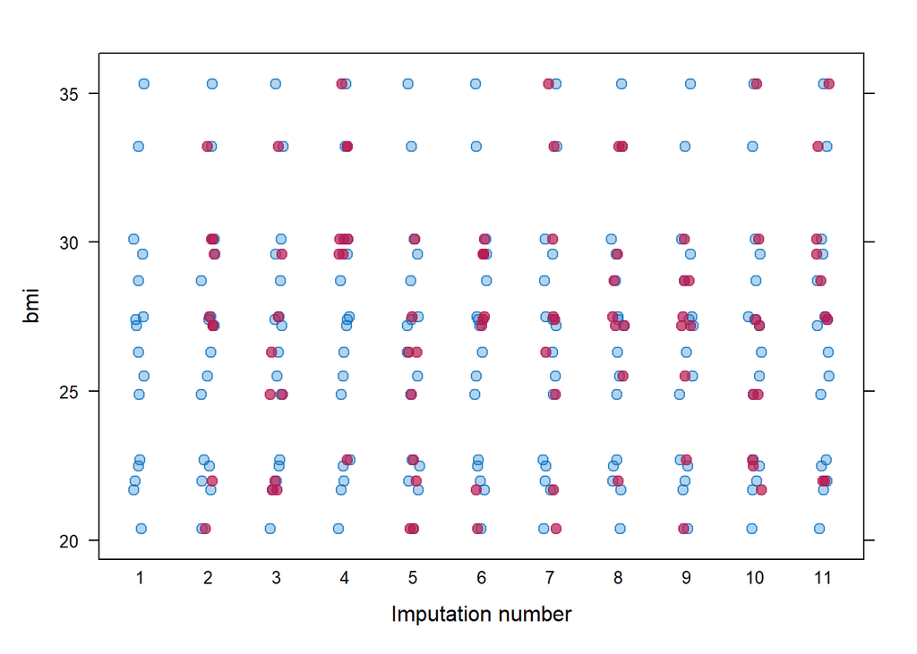

```r
?stripplot
stripplot(imp, bmi~ .imp,
          col = mdc(1:2),  # Select color - 1st num is observed, 2nd num is imputed
          pch = c(21, 20), # Choose fill
          cex = c(1, 1.5) # Choose size
          )
```

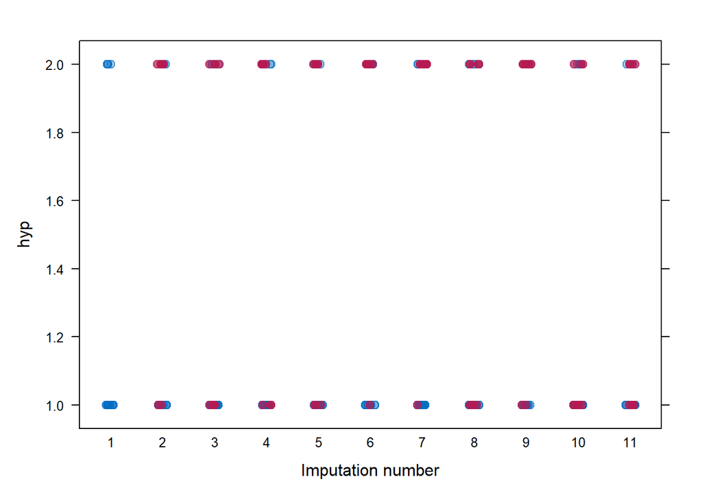

```r
# blue = observed data.
# red = imputed data.

stripplot(imp, hyp~ .imp,
          col = mdc(1:2),
          pch = c(21, 20),
          cex = c(1, 1.5))
```

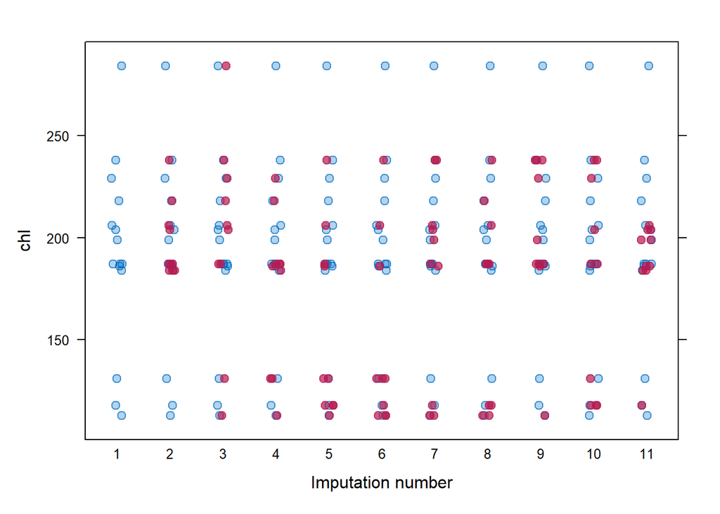

```r
stripplot(imp, chl~ .imp,
          col = mdc(1:2),
          pch = c(21, 20),
          cex = c(1, 1.5))
```

We can see nicely through the stripplots that the imputed value ranges never go beyond the range of our existing values. This is very useful in this scenario, but may not always be appropriate.

### Customising MICE

We can also modify our mice algorhythm if needed to better specify our data. By default it uses predictive mean matching (pmm), as it is robust to both categorical and continuous data - and can be used with smaller samples. But for demonstrative purposes we’ll highlight some of the control we have in this area.

We can also specify which variables we want to be used for the imputation. As a general rule of thumb, the more the merrier - especially to minimise MNAR conditions (Van Buuren, 2018). However, in some cases it may be useful to control as information may cause problematic covariance. In this case, we will remove the shadow `_NA` variables from the mice procedure.

For further details, please check out this useful resource: https://www.rdocumentation.org/packages/mice/versions/3.16.0/topics/mice

```r
#step 1 - initiate mids file under 0 imputation
imp2 <- mice(nhanes_shadow, maxit = 0, print = F )
#step 2 - initiate and view predictor matrix
pred <- imp2$pred
pred
```

```
##        age bmi hyp chl age_NA bmi_NA hyp_NA chl_NA
## age      0   1   1   1      0      1      1      1
## bmi      1   0   1   1      0      1      1      1
## hyp      1   1   0   1      0      1      1      1
## chl      1   1   1   0      0      1      1      1
## age_NA   1   1   1   1      0      1      1      1
## bmi_NA   1   1   1   1      0      0      1      1
## hyp_NA   1   1   1   1      0      1      0      1
## chl_NA   1   1   1   1      0      1      1      0
```

The object `pred` contains the predictor matrix from an initial run of mice with zero iterations. This is specified by setting `maxit = 0`. From here, altering the predictor matrix and returning it to the mice algorithm is very simple. For example, the following code removes the `..._NA` variables from the set of predictors, but still leaves it to be predicted by the other variables.

```r
pred[ ,  "bmi_NA"] <- 0
pred
```

```
##        age bmi hyp chl age_NA bmi_NA hyp_NA chl_NA
## age      0   1   1   1      0      0      1      1
## bmi      1   0   1   1      0      0      1      1
## hyp      1   1   0   1      0      0      1      1
## chl      1   1   1   0      0      0      1      1
## age_NA   1   1   1   1      0      0      1      1
## bmi_NA   1   1   1   1      0      0      1      1
## hyp_NA   1   1   1   1      0      0      0      1
## chl_NA   1   1   1   1      0      0      1      0
```

```r
pred[ ,  "hyp_NA"] <- 0
pred
```

```
##        age bmi hyp chl age_NA bmi_NA hyp_NA chl_NA
## age      0   1   1   1      0      0      0      1
## bmi      1   0   1   1      0      0      0      1
## hyp      1   1   0   1      0      0      0      1
## chl      1   1   1   0      0      0      0      1
## age_NA   1   1   1   1      0      0      0      1
## bmi_NA   1   1   1   1      0      0      0      1
## hyp_NA   1   1   1   1      0      0      0      1
## chl_NA   1   1   1   1      0      0      0      0
```

```r
pred[ ,  "chl_NA"] <- 0
pred
```

```
##        age bmi hyp chl age_NA bmi_NA hyp_NA chl_NA
## age      0   1   1   1      0      0      0      0
## bmi      1   0   1   1      0      0      0      0
## hyp      1   1   0   1      0      0      0      0
## chl      1   1   1   0      0      0      0      0
## age_NA   1   1   1   1      0      0      0      0
## bmi_NA   1   1   1   1      0      0      0      0
## hyp_NA   1   1   1   1      0      0      0      0
## chl_NA   1   1   1   1      0      0      0      0
```

This can now be used for imputing a new predictor matrix

```r
imp3 <- mice(nhanes_shadow, pred = pred, print = F)
summary(imp3)
```

```
## Class: mids
## Number of multiple imputations:  5
## Imputation methods:
##      age      bmi      hyp      chl   age_NA   bmi_NA   hyp_NA   chl_NA
##       ""    "pmm" "logreg"    "pmm"       ""       ""       ""       ""
## PredictorMatrix:
##        age bmi hyp chl age_NA bmi_NA hyp_NA chl_NA
## age      0   1   1   1      0      0      0      0
## bmi      1   0   1   1      0      0      0      0
## hyp      1   1   0   1      0      0      0      0
## chl      1   1   1   0      0      0      0      0
## age_NA   1   1   1   1      0      0      0      0
## bmi_NA   1   1   1   1      0      0      0      0
```

But what if we’re working with a large dataset with many variables? Or if we want to only include variables with a minimum correlation effect size? For this, we can use the `quickpred()` function. In this instance, we will set mice to only impute across variables with a minimum correlation of *r* = .2 .

```r
?quickpred

ini <- mice(nhanes_shadow, pred = quickpred(nhanes_shadow, mincor = .2), print = F)
summary(ini)
```

```
## Class: mids
## Number of multiple imputations:  5
## Imputation methods:
##      age      bmi      hyp      chl   age_NA   bmi_NA   hyp_NA   chl_NA
##       ""    "pmm" "logreg"    "pmm"       ""       ""       ""       ""
## PredictorMatrix:
##        age bmi hyp chl age_NA bmi_NA hyp_NA chl_NA
## age      0   0   0   0      0      0      0      0
## bmi      1   0   0   1      0      1      1      1
## hyp      1   0   0   1      0      1      1      1
## chl      1   1   1   0      0      1      1      1
## age_NA   0   0   0   0      0      0      0      0
## bmi_NA   0   0   0   0      0      0      0      0
## Number of logged events:  75
##   it im dep   meth                out
## 1  1  1 bmi    pmm bmi_NANA, hyp_NANA
## 2  1  1 hyp logreg           hyp_NANA
## 3  1  1 chl    pmm           chl_NANA
## 4  1  2 bmi    pmm bmi_NANA, hyp_NANA
## 5  1  2 hyp logreg           hyp_NANA
## 6  1  2 chl    pmm           chl_NANA
```

```r
#first step - removing _NA variables
nhanes_new <- nhanes_shadow %>% select(!contains("_NA")) # using !contains to select all variables not with `_NA`
summary(nhanes_new)
```

```
##     age          bmi          hyp          chl
##  20-39:12   Min.   :20.40   0   :13   Min.   :113.0
##  40-59: 7   1st Qu.:22.65   1   : 4   1st Qu.:185.0
##  60-99: 6   Median :26.75   NA's: 8   Median :187.0
##             Mean   :26.56             Mean   :191.4
##             3rd Qu.:28.93             3rd Qu.:212.0
##             Max.   :35.30             Max.   :284.0
##             NA's   :9                 NA's   :10
```

```r
imp4 <- mice(nhanes_new, m = 10 , maxit = 10,
             pred = quickpred(nhanes_new, mincor = .2),
             meth = c("", "norm", "rf", "norm"),
             print = FALSE
             )

summary(imp4)
```

```
## Class: mids
## Number of multiple imputations:  10
## Imputation methods:
##    age    bmi    hyp    chl
##     "" "norm"   "rf" "norm"
## PredictorMatrix:
##     age bmi hyp chl
## age   0   0   0   0
## bmi   1   0   0   1
## hyp   1   0   0   1
## chl   1   1   1   0
```

```r
# Updated list of methods available
methods(mice)
```

```
##  [1] mice.impute.2l.bin              mice.impute.2l.lmer
##  [3] mice.impute.2l.norm             mice.impute.2l.pan
##  [5] mice.impute.2lonly.mean         mice.impute.2lonly.norm
##  [7] mice.impute.2lonly.pmm          mice.impute.cart
##  [9] mice.impute.jomoImpute          mice.impute.lasso.logreg
## [11] mice.impute.lasso.norm          mice.impute.lasso.select.logreg
## [13] mice.impute.lasso.select.norm   mice.impute.lda
## [15] mice.impute.logreg              mice.impute.logreg.boot
## [17] mice.impute.mean                mice.impute.midastouch
## [19] mice.impute.mnar.logreg         mice.impute.mnar.norm
## [21] mice.impute.mpmm                mice.impute.norm
## [23] mice.impute.norm.boot           mice.impute.norm.nob
## [25] mice.impute.norm.predict        mice.impute.panImpute
## [27] mice.impute.passive             mice.impute.pmm
## [29] mice.impute.polr                mice.impute.polyreg
## [31] mice.impute.quadratic           mice.impute.rf
## [33] mice.impute.ri                  mice.impute.sample
## [35] mice.mids                       mice.theme
## see '?methods' for accessing help and source code
```

Lets compare the strip plots

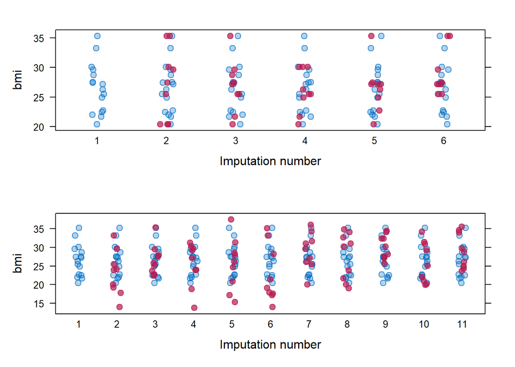

```r
bmi_standard <- stripplot(imp3, bmi~ .imp,
           col = mdc(1:2),
          pch = c(21, 20),
          cex = c(1, 1.5))

bmi_mod <- stripplot(imp4, bmi~ .imp,
           col = mdc(1:2),
          pch = c(21, 20),
          cex = c(1, 1.5))


grid.arrange(bmi_standard, bmi_mod)
```

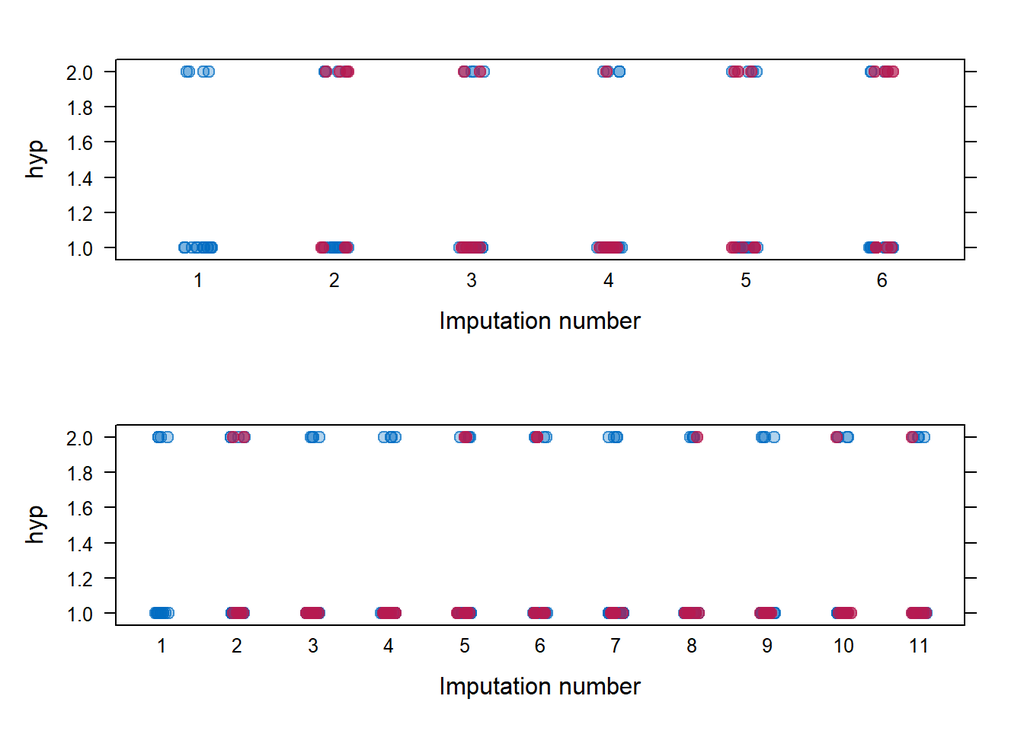

```r
hyp_standard <- stripplot(imp3, hyp~ .imp,
           col = mdc(1:2),
          pch = c(21, 20),
          cex = c(1, 1.5))

hyp_mod <- stripplot(imp4, hyp~ .imp,
           col = mdc(1:2),
          pch = c(21, 20),
          cex = c(1, 1.5))


grid.arrange(hyp_standard, hyp_mod)
```

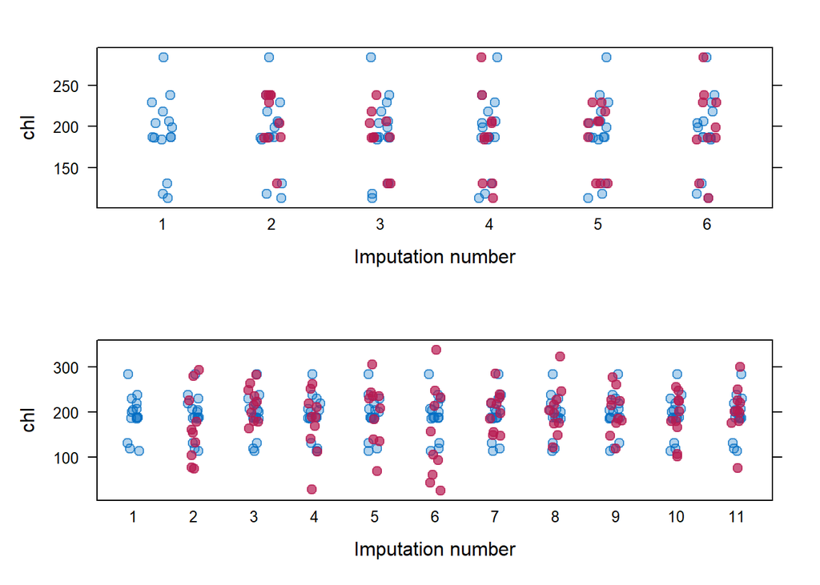

```r
chl_standard <- stripplot(imp3, chl~ .imp,
           col = mdc(1:2),
          pch = c(21, 20),
          cex = c(1, 1.5))

chl_mod <- stripplot(imp4, chl~ .imp,
           col = mdc(1:2),
          pch = c(21, 20),
          cex = c(1, 1.5))


grid.arrange(chl_standard, chl_mod)
```

And now to compare convergence plots - here mice implements an iterative Markov Monte Carlo type of algorithm. We can use the trace lines to study the convergence:

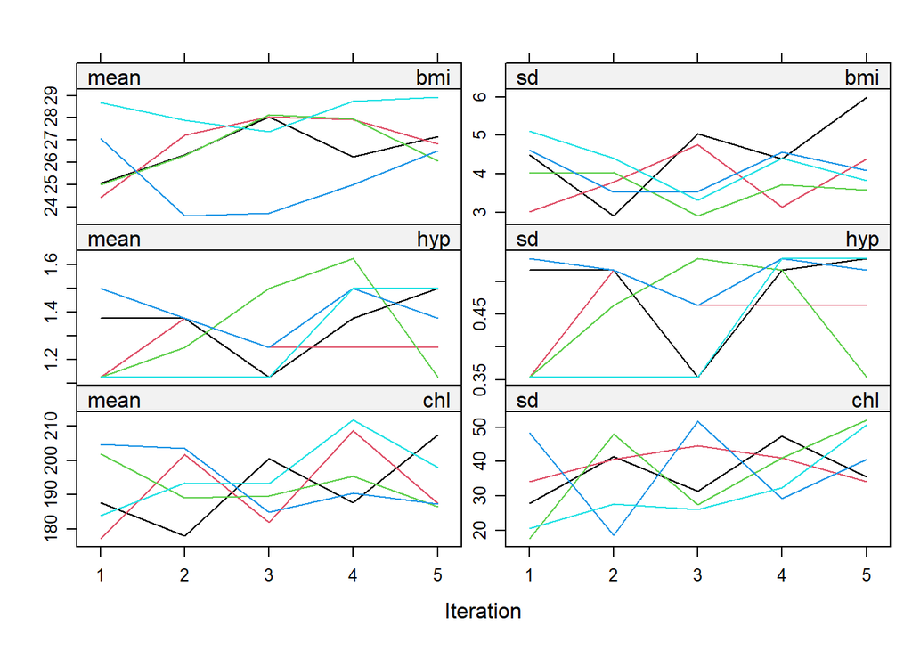

```r
 plot(imp3, title = "model convergence for default mice")
```

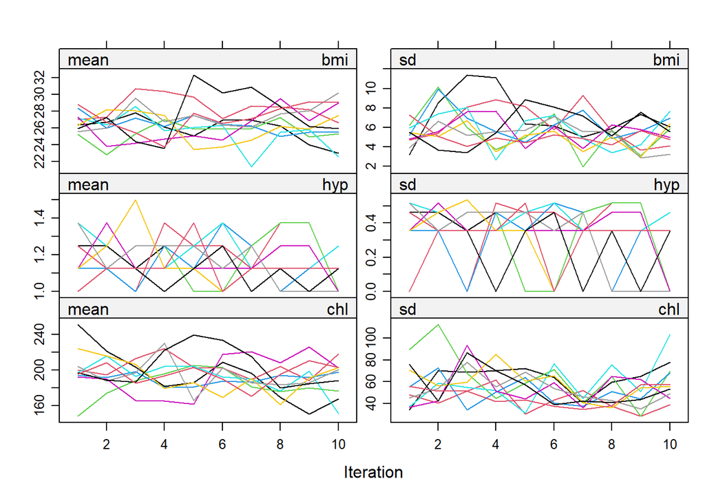

```r
 plot(imp4, title = "model convergence for customised mice")
```

The convergence plot shows the mean (left) and standard deviation (right) of the imputed values. In general, we are looking for the streams to intertwine, and to be free of trends at the later stages/iterations.

### Step 2 Perform analysis on each dataset

```r
fit <- with(imp3, lm(chl ~ age + bmi + hyp))
fit2 <- with(imp4, lm(chl ~ age + bmi + hyp))
```

### Step 3 - Combine the results

Our final step is to combine and pool the results. Conceptually this gets a little weird, but practically it is simple. The key thing to note here is *averaging* the values from previous steps is bad practice (Van Buurel, 2018). This is because it yields incorrect standard errors, confidence intervals and p-values. As a result, it should not be used if any form of statistical testing or uncertainty analysis is to be done on the imputed data. This is because averaging the datasets ignores the between-imputation variability. Doing so will provide all the drawbacks of single imputation.

So instead we *pool* our data. This allows us to *average* the *estimates* of the complete data model to compute the total variance through the repeated analyses conducted above. This ensures that the analyses of the multiple imputation are done in accordance with Rubin’s rules (Rubin 1987). (In other words - fancy stats talk for best recommended practice).

```r
est <- pool(fit)

est
```

```
## Class: mipo    m = 5
##          term m   estimate        ubar           b          t dfcom        df
## 1 (Intercept) 5  0.2816934 3339.803869 965.3015270 4498.16570    20 11.070000
## 2    age40-59 5 50.1010421  440.248466 238.9754470  727.01900    20  7.732156
## 3    age60-99 5 72.7713775  545.377526 422.0862960 1051.88108    20  6.112984
## 4         bmi 5  6.1073286    3.981312   0.9034146    5.06541    20 12.326734
## 5        hyp1 5 -9.7896858  426.101439 365.9164909  865.20123    20  5.695203
##         riv    lambda       fmi
## 1 0.3468353 0.2575187 0.3630598
## 2 0.6513834 0.3944471 0.5072954
## 3 0.9287210 0.4815217 0.5953106
## 4 0.2722965 0.2140197 0.3165830
## 5 1.0305053 0.5075117 0.6207899
```

```r
summary(est)
```

```
##          term   estimate std.error    statistic        df    p.value
## 1 (Intercept)  0.2816934 67.068366  0.004200094 11.070000 0.99672355
## 2    age40-59 50.1010421 26.963290  1.858120514  7.732156 0.10150190
## 3    age60-99 72.7713775 32.432716  2.243764506  6.112984 0.06519106
## 4         bmi  6.1073286  2.250646  2.713588618 12.326734 0.01844775
## 5        hyp1 -9.7896858 29.414303 -0.332820591  5.695203 0.75117736
```

```r
pool.r.squared(est)
```

```
##           est     lo 95     hi 95       fmi
## R^2 0.4758304 0.1231474 0.7550284 0.2672849
```

```r
est2 <- pool(fit2)

est2
```

```
## Class: mipo    m = 10
##          term  m   estimate        ubar          b           t dfcom        df
## 1 (Intercept) 10 -35.224961 2176.390946 1714.66607 4062.523627    20  7.925774
## 2    age40-59 10  51.844560  339.291109  363.56343  739.210882    20  6.586291
## 3    age60-99 10  85.172397  379.572813  232.00304  634.776161    20  9.129085
## 4         bmi 10   7.192038    2.604567    1.95396    4.753922    20  8.152246
## 5        hyp1 10   6.853997  371.031375   89.11929  469.062595    20 13.498217
##         riv    lambda       fmi
## 1 0.8666332 0.4642761 0.5623422
## 2 1.1786922 0.5410090 0.6367689
## 3 0.6723436 0.4020368 0.5006366
## 4 0.8252257 0.4521225 0.5503767
## 5 0.2642127 0.2089939 0.3048838
```

```r
summary(est2)
```

```
##          term   estimate std.error  statistic        df     p.value
## 1 (Intercept) -35.224961 63.737929 -0.5526531  7.925774 0.595738751
## 2    age40-59  51.844560 27.188433  1.9068609  6.586291 0.100834085
## 3    age60-99  85.172397 25.194765  3.3805593  9.129085 0.007956075
## 4         bmi   7.192038  2.180349  3.2985719  8.152246 0.010599674
## 5        hyp1   6.853997 21.657853  0.3164671 13.498217 0.756488967
```

```r
pool.r.squared(est2)
```

```
##           est     lo 95     hi 95       fmi
## R^2 0.6755164 0.2354223 0.8955577 0.5918943
```

### Calculating Means and SD

```r
imp3 %>% mice::complete("long") %>%
  select(bmi, chl ) %>%
  summarise_all(list(~mean(.), ~sd(.)))
```

```
##   bmi_mean chl_mean   bmi_sd   chl_sd
## 1  26.7528   192.16 4.190727 43.15602
```

```r
imp4 %>% mice::complete("long") %>%
  select(bmi, chl ) %>%
  summarise_all(list(~mean(.), ~sd(.)))
```

```
##   bmi_mean chl_mean   bmi_sd   chl_sd
## 1  26.5372 191.1724 4.812418 52.92375
```

```r
#Grouped summary (by Age)
imp3 %>% mice::complete("long") %>%
  select(age, bmi, chl ) %>%
  group_by(age) %>%
  summarise_all(list(~mean(.), ~sd(.)))
```

```
## # A tibble: 3 × 5
##   age   bmi_mean chl_mean bmi_sd chl_sd
##   <fct>    <dbl>    <dbl>  <dbl>  <dbl>
## 1 20-39     28.5     175.   4.69   45.8
## 2 40-59     25.4     199.   3.19   25.4
## 3 60-99     24.8     219.   2.41   38.8
```

```r
imp4 %>% mice::complete("long") %>%
  select(age, bmi, chl ) %>%
  group_by(age) %>%
  summarise_all(list(~mean(.), ~sd(.)))
```

```
## # A tibble: 3 × 5
##   age   bmi_mean chl_mean bmi_sd chl_sd
##   <fct>    <dbl>    <dbl>  <dbl>  <dbl>
## 1 20-39     28.2     167.   5.25   50.0
## 2 40-59     25.3     201.   3.66   42.8
## 3 60-99     24.6     228.   3.88   44.3
```

We can also inspect density plots to evaluate the imputation. If all goes well, the red and blue lines should be very closely associated.

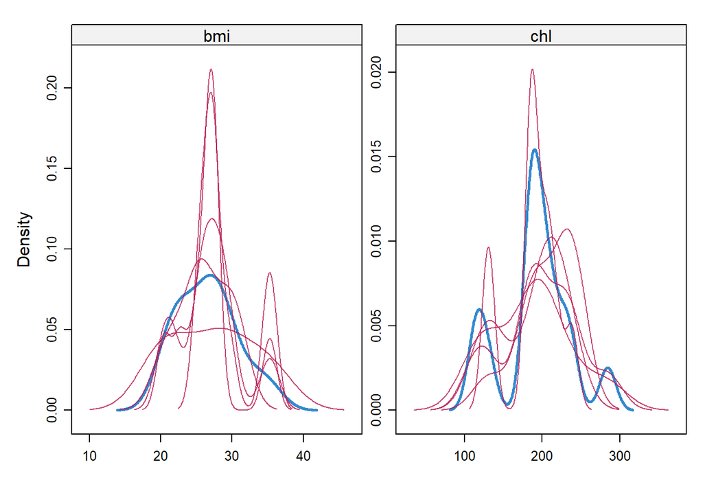

```r
densityplot(imp3)
```

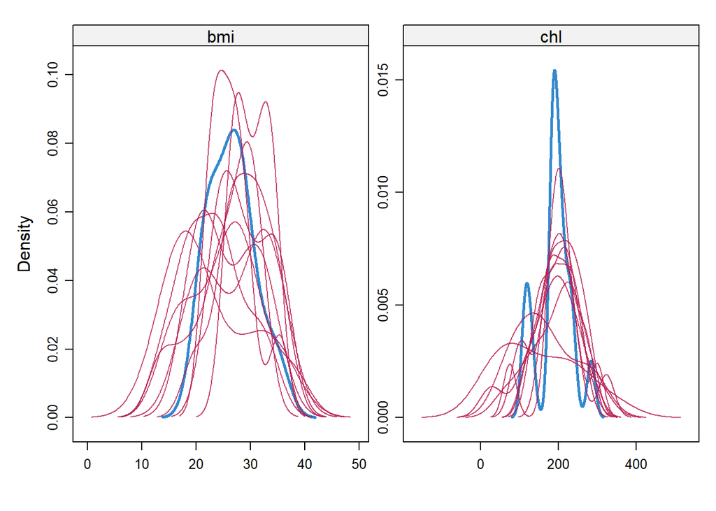

```r
densityplot(imp4)
```

### Step 4 - Evaluate imputation

To evaluate our imputation there are several key steps: 1. we need to study our stripplots - Make sure there are no imputation in inappropriate ranges. 2. Inspect our *convergence plots* - There should be plenty of overlap, but with no set pattern at end (if problematic, you test to see if this can be fixed by increasing `m = ...` in mice). 3. Inpect pooled analysis results (specifically the *lambda* and *fmi*). Generally speaking - the lower the better for these two measures. 4. Check *density plots* - The two colours should be closely aligned.

After considering these points, we can decide if we believe that interpreting the pooled regression coefficients are reliable and ready for reporting in our analysis.

## What about item level imputation?

One simple solution is the person mean/row mean imputation - but beware as this is only usable in conditions where under 10% of data is missing per case. I would also be consider cronbach alpha’s when using this method - as it is done under the assumption of internal consistency. https://www.sciencedirect.com/science/article/pii/S0895435613003879 * person mean imputation will bias if over 10% is missing.

An other solution is to use MICE again. The procedure is similar to previous steps, but we need to add an additional step to calculate the scale/subscale total.

For the following examples we will use a psychology dataset that investigates the relationship between stressful life events, social support and distress (via the DASS-21 measure, which is broken down into the subscales of stress, depression and anxiety). The dataset is borrowed from the MSc Psychology Conversion Course - Psychological Research Methods module. Much like the previous session, we will deliberately create MAR missing data in order to provide a suitable demonstration. This missing data will be across some of the DASS items, and will be conditional upon the group, eventsscore and SOsupport.

### Simulating missing data and some metadata details

```r
life_events <- read_csv("https://raw.githubusercontent.com/DCS-training/Much-ado-about-nothing-missing-data-in-research/main/Lifeevents.csv")
life_events_1 <- life_events %>% mutate(group = as.factor(group))

# group = intervention group. 1 = control group. 2 = mindfulness intervention.
# eventsscore = count data. Lists number of stressful life events participant exposed to.
# DASS stress subscale = dass1, dass6, dass8, dass11, dass12, dass14, dass18
# DASS anxiety subscale = dass2, dass4, dass7, dass9, dass15, dass19, dass20
# DASS depression subscale = dass3, dass5, dass10, dass16, dass17, dass21
# SOsupport - significant other social support.
# friendsupport - social support from friends.
# famsupport - social support from family.

MAR_lifeevents <- delete_MAR_censoring(life_events_1, cols_mis = c("dass3", "dass5", "dass10"),
                                        cols_ctrl = c("eventsscore","SOsupport", "group" ),  .2)  # Creating missing data in depression subscale
```

Time to get compare the descriptive stats of the original and the missing data.

```r
#step 1 - calculate subscales
original <- life_events_1 %>%
  mutate(Stress_subscale = dass1 + dass6+ dass8 +
           dass11 + dass12 + dass14 + dass18,
         Anxiety_subcale = dass2 + dass4 + dass7 + dass9 +
           dass15+ dass19+ dass20,
         Depresion_subscale = dass3 + dass5 + dass10 + dass16 + dass17 + dass21)

original_summary <- original %>% dplyr::select(`Stress_subscale`, `Anxiety_subcale`, `Depresion_subscale`, `SOsupport`, `group`, `eventsscore`) %>% # selecting to avoid summaries of shadow variables.
  tbl_summary( statistic = list(
      all_continuous() ~ "{mean} ({sd})",
      all_categorical() ~ "{n} / {N} ({p}%)"
    ))

# Checking cronbach alpha (just for depression for demonstration)
original_alpha_depression <- original %>% select(dass3, dass5, dass10, dass16, dass17, dass21)
ltm::cronbach.alpha(original_alpha_depression)
```

```
##
## Cronbach's alpha for the 'original_alpha_depression' data-set
##
## Items: 6
## Sample units: 40
## alpha: 0.953
```

```r
MAR <- MAR_lifeevents %>%
  mutate(Stress_subscale = dass1 + dass6+ dass8 +
           dass11 + dass12 + dass14 + dass18,
         Anxiety_subcale = dass2 + dass4 + dass7 + dass9 +
           dass15+ dass19+ dass20,
         Depresion_subscale = dass3 + dass5 + dass10 + dass16 + dass17 + dass21) %>% bind_shadow()

MAR_summary <- original %>% dplyr::select(`Stress_subscale`, `Anxiety_subcale`, `Depresion_subscale`, `SOsupport`, `group`, `eventsscore`) %>% # selecting to avoid summaries of shadow variables.
  tbl_summary( statistic = list(
      all_continuous() ~ "{mean} ({sd})",
      all_categorical() ~ "{n} / {N} ({p}%)"
    ))

tbl_merge(tbls = list(original_summary, MAR_summary),
          tab_spanner = c("Original", "MAR"))
```

| **Characteristic** | Original **N = 40**<sup>1</sup> | MAR **N = 40**<sup>1</sup> |
| --- | --- | --- |
| Stress_subscale | 9.0 (6.4) | 9.0 (6.4) |
| Anxiety_subcale | 6.1 (5.6) | 6.1 (5.6) |
| Depresion_subscale | 6.3 (5.5) | 6.3 (5.5) |
| SOsupport | 22.7 (5.9) | 22.7 (5.9) |
| group |  |  |
| 1 | 16 / 40 (40%) | 16 / 40 (40%) |
| 2 | 24 / 40 (60%) | 24 / 40 (60%) |
| eventsscore | 3.80 (2.26) | 3.80 (2.26) |

<sup>1</sup> Mean (SD); n / N (%)

```r
alpha_depression <- MAR %>% select(dass3, dass5, dass10, dass16, dass17, dass21)
#ltm::cronbach.alpha(alpha_depression) does not work due to missing data


## Setting regression models to compare

model_original <- lm(Depresion_subscale ~ eventsscore + SOsupport, original )
model_MAR <- lm(Depresion_subscale ~ eventsscore + SOsupport , MAR )

Original_reg_summary <- tbl_regression(model_original) %>%
  modify_column_unhide(column = std.error) %>%
  add_glance_table(include = c(r.squared, adj.r.squared,
                               statistic, df.residual, p.value))

MAR_reg_summary <- tbl_regression(model_MAR) %>%
  modify_column_unhide(column = std.error) %>%
  add_glance_table(include = c(r.squared, adj.r.squared,
                               statistic, df.residual, p.value))

tbl_merge(tbls = list(Original_reg_summary, MAR_reg_summary),
          tab_spanner = c("Original", "MAR"))
```

| **Characteristic** | Original **Beta** | Original **SE**<sup>1</sup> | Original **95% CI**<sup>1</sup> | Original **p-value** | MAR **Beta** | MAR **SE**<sup>1</sup> | MAR **95% CI**<sup>1</sup> | MAR **p-value** |
| --- | --- | --- | --- | --- | --- | --- | --- | --- |
| eventsscore | 0.83 | 0.352 | 0.12, 1.5 | 0.024 | 0.28 | 0.648 | -1.1, 1.6 | 0.7 |
| SOsupport | -0.31 | 0.135 | -0.58, -0.03 | 0.028 | 0.20 | 0.400 | -0.64, 1.0 | 0.6 |
| R² | 0.252 |  |  |  | 0.031 |  |  |  |
| Adjusted R² | 0.212 |  |  |  | -0.077 |  |  |  |
| Statistic | 6.24 |  |  |  | 0.284 |  |  |  |
| Residual df | 37 |  |  |  | 18 |  |  |  |
| p-value | 0.005 |  |  |  | 0.8 |  |  |  |

<sup>1</sup> SE = Standard Error, CI = Confidence Interval

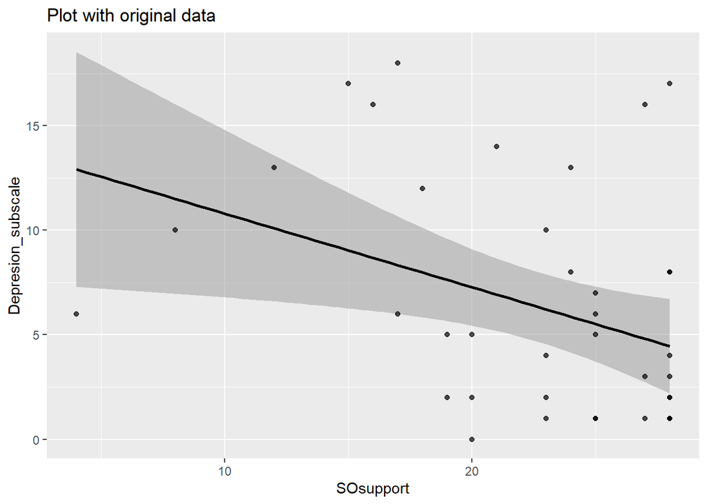

```r
# Plots to compare

original_plot <- ggplot(original, aes(
  y = Depresion_subscale,
  x = SOsupport
)) +
  geom_smooth(method = "lm", formula = y ~ x, color = "black", alpha = .5) +
  geom_point(alpha =.7)+
  theme(legend.position = "bottom") +
  labs(title = "Plot with original data")

MAR_plot <- ggplot(MAR, aes(
  y = Depresion_subscale,
  x = SOsupport
)) +
  geom_smooth(method = "lm", formula = y ~ x, color = "black", alpha = .5) +
  geom_miss_point() +
  theme(legend.position = "bottom") +
  labs(title = "Plot with missing data")

original_plot
```

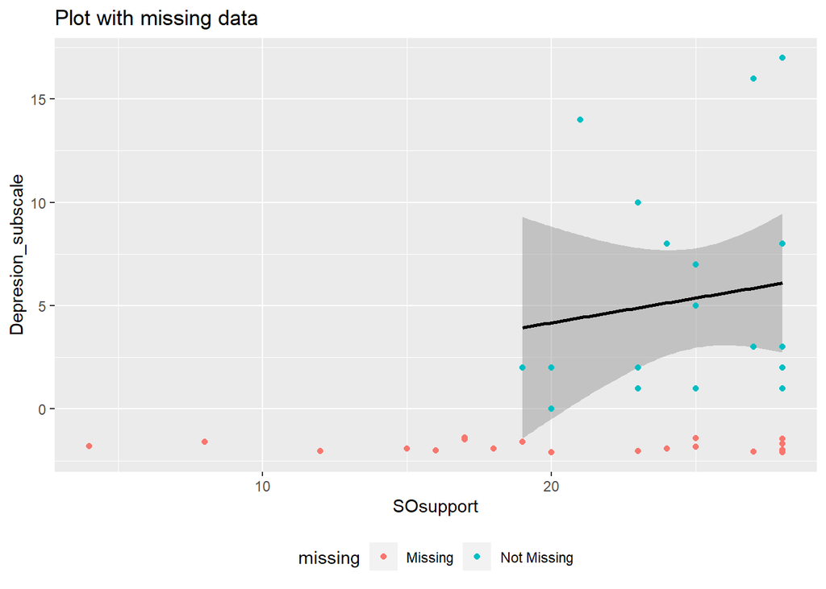

```r
MAR_plot
```

### Person mean imputation code

```r
# Step 1 - selecting only variables in subscale
Depression_data <- MAR_lifeevents  %>%
  select(dass3, dass5, dass10, dass16, dass17, dass21)


#Step 2 - applying rowwise imputation to the selected data
Depression_fix <- apply_imputation(Depression_data, FUN = mean, type = "rowwise")

#Step 3 - updating dataset with imputed data
MAR_rowwise_mean_imp <- MAR_lifeevents %>% mutate(
  dass3 = Depression_fix$dass3,
  dass5 = Depression_fix$dass5,
  dass10 = Depression_fix$dass10,
  dass16 = Depression_fix$dass16,
  dass17 = Depression_fix$dass17,
  dass21 = Depression_fix$dass21,
  Stress_subscale = dass1 + dass6+ dass8 + dass11 + dass12 + dass14 + dass18,
         Anxiety_subcale = dass2 + dass4 + dass7 + dass9 + dass15+ dass19+ dass20,
         Depresion_subscale = dass3 + dass5 + dass10 + dass16 + dass17 + dass21
) %>% bind_shadow()
```

### Comparing row wise imputation with previous data

```r
MAR_rowwise_summary <- MAR_rowwise_mean_imp %>% dplyr::select(`Stress_subscale`, `Anxiety_subcale`, `Depresion_subscale`, `SOsupport`, `group`, `eventsscore`) %>% # selecting to avoid summaries of shadow variables.
  tbl_summary( statistic = list(
      all_continuous() ~ "{mean} ({sd})",
      all_categorical() ~ "{n} / {N} ({p}%)"
    ))

tbl_merge(tbls = list(original_summary, MAR_summary, MAR_rowwise_summary),
          tab_spanner = c("Original", "MAR", "Rowwise-imp"))
```

| **Characteristic** | Original **N = 40**<sup>1</sup> | MAR **N = 40**<sup>1</sup> | Rowwise-imp **N = 40**<sup>1</sup> |
| --- | --- | --- | --- |
| Stress_subscale | 9.0 (6.4) | 9.0 (6.4) | 9.0 (6.4) |
| Anxiety_subcale | 6.1 (5.6) | 6.1 (5.6) | 6.1 (5.6) |
| Depresion_subscale | 6.3 (5.5) | 6.3 (5.5) | 6.4 (5.5) |
| SOsupport | 22.7 (5.9) | 22.7 (5.9) | 22.7 (5.9) |
| group |  |  |  |
| 1 | 16 / 40 (40%) | 16 / 40 (40%) | 16 / 40 (40%) |
| 2 | 24 / 40 (60%) | 24 / 40 (60%) | 24 / 40 (60%) |
| eventsscore | 3.80 (2.26) | 3.80 (2.26) | 3.80 (2.26) |

<sup>1</sup> Mean (SD); n / N (%)

```r
# Comparing cronbach alphas
alpha_depression <- MAR_rowwise_mean_imp %>% select(dass3, dass5, dass10, dass16, dass17, dass21)

ltm::cronbach.alpha(alpha_depression)
```

```
##
## Cronbach's alpha for the 'alpha_depression' data-set
##
## Items: 6
## Sample units: 40
## alpha: 0.956
```

```r
ltm::cronbach.alpha(original_alpha_depression)
```

```
##
## Cronbach's alpha for the 'original_alpha_depression' data-set
##
## Items: 6
## Sample units: 40
## alpha: 0.953
```

```r
## Setting regression models to compare


model_rowwise_MAR <- lm(Depresion_subscale ~ eventsscore + SOsupport  , MAR_rowwise_mean_imp )


MAR_rowise_imp_summary <- tbl_regression(model_rowwise_MAR) %>%
  modify_column_unhide(column = std.error) %>%
  add_glance_table(include = c(r.squared, adj.r.squared,
                               statistic, df.residual, p.value))

tbl_merge(tbls = list(Original_reg_summary, MAR_reg_summary, MAR_rowise_imp_summary),
          tab_spanner = c("Original", "MAR", "Rowwise-imp"))
```

| **Characteristic** | Original **Beta** | Original **SE**<sup>1</sup> | Original **95% CI**<sup>1</sup> | Original **p-value** | MAR **Beta** | MAR **SE**<sup>1</sup> | MAR **95% CI**<sup>1</sup> | MAR **p-value** | Rowwise-imp **Beta** | Rowwise-imp **SE**<sup>1</sup> | Rowwise-imp **95% CI**<sup>1</sup> | Rowwise-imp **p-value** |
| --- | --- | --- | --- | --- | --- | --- | --- | --- | --- | --- | --- | --- |
| eventsscore | 0.83 | 0.352 | 0.12, 1.5 | 0.024 | 0.28 | 0.648 | -1.1, 1.6 | 0.7 | 0.82 | 0.353 | 0.10, 1.5 | 0.026 |
| SOsupport | -0.31 | 0.135 | -0.58, -0.03 | 0.028 | 0.20 | 0.400 | -0.64, 1.0 | 0.6 | -0.31 | 0.136 | -0.59, -0.04 | 0.027 |
| R² | 0.252 |  |  |  | 0.031 |  |  |  | 0.251 |  |  |  |
| Adjusted R² | 0.212 |  |  |  | -0.077 |  |  |  | 0.210 |  |  |  |
| Statistic | 6.24 |  |  |  | 0.284 |  |  |  | 6.19 |  |  |  |
| Residual df | 37 |  |  |  | 18 |  |  |  | 37 |  |  |  |
| p-value | 0.005 |  |  |  | 0.8 |  |  |  | 0.005 |  |  |  |

<sup>1</sup> SE = Standard Error, CI = Confidence Interval

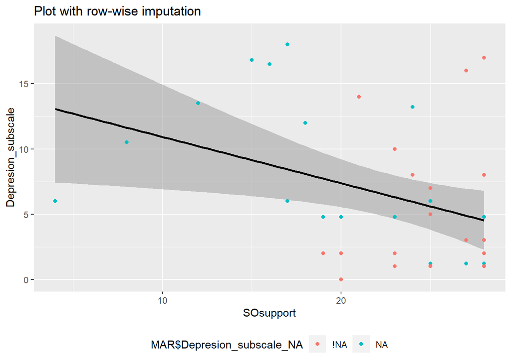

```r
#Comparing and inspecting plots

MAR_rowwise_imp_plot <- ggplot(MAR_rowwise_mean_imp, aes(
  y = Depresion_subscale,
  x = SOsupport
)) +
  geom_smooth(method = "lm", formula = y ~ x, color = "black", alpha = .5) +
  geom_point(aes(color = MAR$Depresion_subscale_NA)) +
  theme(legend.position = "bottom") +
  labs(title = "Plot with row-wise imputation")

MAR_rowwise_imp_plot
```

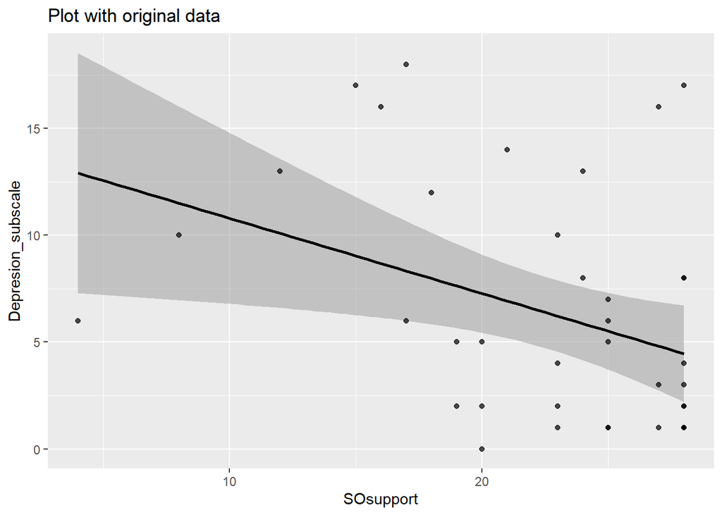

```r
original_plot
```

## Item level imputation / Passive imputation with MICE

Multi item level imputation through mice is possible, but it is difficult. It is even thought to be unpractical when working with datasets with many variables (as is often the case with psychometric data…). However, the method is reccomended when faced with large % of missing data.

```r
# This gets a little complicated...


# meth = c("", "logreg", "pmm",
#                   "rf", "rf", "rf", "rf", "rf", "rf", "rf", # Set to DASS
#                   "rf", "rf", "rf", "rf", "rf", "rf", "rf", # rf (random forest) is effective for Likert items
#                   "rf", "rf", "rf", "rf", "rf", "rf", "rf",
#                   "pmm", "pmm", "pmm"),

imp <-mice(MAR_lifeevents,
                  meth = c("", "logreg", "pmm",
                  "rf", "rf", "rf", "rf", "rf", "rf", "rf", # Set to DASS
                  "rf", "rf", "rf", "rf", "rf", "rf", "rf", # rf (random forest) is effective for Likert items
                  "rf", "rf", "rf", "rf", "rf", "rf", "rf",
                  "pmm", "pmm", "pmm"),
            seed = 123, print = FALSE, pred = quickpred(MAR_lifeevents, mincor = .6), m =10)
# From there, we get to follow the usual mice routine


## Setting the model we want to test
fit <- with(imp, lm(I(dass3 + dass5 + dass10 + dass16 + dass17 + dass21) ~ eventsscore + SOsupport ))

## Second method - here we can use tidyverse wranging strategies

imp_m <- imp %>%
  mice::complete("long", include = TRUE) %>%
  mutate(Depression_subscale = (dass3 + dass5 + dass10 + dass16 + dass17 + dass21)) # any additional data wrangling can be performed here if needed

imp_mids <- as.mids(imp_m) # After data wrangling, the data needs to be converted to `mids` format so that it can be pooled correctly.

fit2 <- with(imp_mids, lm(Depression_subscale ~ eventsscore + SOsupport))


## Pooling the results
est <- pool.syn(fit)
est
```

```
## Class: mipo    m = 10
##          term  m   estimate        ubar            b           t dfcom       df
## 1 (Intercept) 10 10.6792421 13.12171707 0.2140664695 13.14312371    37  3392676
## 2 eventsscore 10  0.8128021  0.12585613 0.0006482625  0.12592096    37 33957580
## 3   SOsupport 10 -0.3201714  0.01854565 0.0003194214  0.01857759    37  3044339
##           riv lambda fmi
## 1 0.017945298     NA  NA
## 2 0.005665904     NA  NA
## 3 0.018945880     NA  NA
```

```r
est2 <- pool.syn(fit2)
est2
```

```
## Class: mipo    m = 10
##          term  m   estimate        ubar            b           t dfcom       df
## 1 (Intercept) 10 10.6792421 13.12171707 0.2140664695 13.14312371    37  3392676
## 2 eventsscore 10  0.8128021  0.12585613 0.0006482625  0.12592096    37 33957580
## 3   SOsupport 10 -0.3201714  0.01854565 0.0003194214  0.01857759    37  3044339
##           riv lambda fmi
## 1 0.017945298     NA  NA
## 2 0.005665904     NA  NA
## 3 0.018945880     NA  NA
```

```r
## Viewing the results
summary(est)
```

```
##          term   estimate std.error statistic       df     p.value
## 1 (Intercept) 10.6792421 3.6253446  2.945718  3392676 0.003222084
## 2 eventsscore  0.8128021 0.3548534  2.290529 33957580 0.021990673
## 3   SOsupport -0.3201714 0.1362996 -2.349026  3044339 0.018822652
```

```r
pool.r.squared(est, adjusted = TRUE)
```

```
##              est      lo 95     hi 95        fmi
## adj R^2 0.211957 0.02949912 0.4572869 0.01299958
```

```r
summary(est2)
```

```
##          term   estimate std.error statistic       df     p.value
## 1 (Intercept) 10.6792421 3.6253446  2.945718  3392676 0.003222084
## 2 eventsscore  0.8128021 0.3548534  2.290529 33957580 0.021990673
## 3   SOsupport -0.3201714 0.1362996 -2.349026  3044339 0.018822652
```

```r
pool.r.squared(est2, adjusted = TRUE)
```

```
##              est      lo 95     hi 95        fmi
## adj R^2 0.211957 0.02949912 0.4572869 0.01299958
```

```r
## Evaluating the results
summary(model_rowwise_MAR)
```

```
##
## Call:
## lm(formula = Depresion_subscale ~ eventsscore + SOsupport, data = MAR_rowwise_mean_imp)
##
## Residuals:
##    Min     1Q Median     3Q    Max
## -7.202 -3.889 -0.816  3.136 11.580
##
## Coefficients:
##             Estimate Std. Error t value Pr(>|t|)
## (Intercept)  10.3945     3.6047   2.884  0.00652 **
## eventsscore   0.8188     0.3530   2.319  0.02600 *
## SOsupport    -0.3123     0.1355  -2.304  0.02692 *
## ---
## Signif. codes:  0 '***' 0.001 '**' 0.01 '*' 0.05 '.' 0.1 ' ' 1
##
## Residual standard error: 4.926 on 37 degrees of freedom
## Multiple R-squared:  0.2506, Adjusted R-squared:  0.2101
## F-statistic: 6.188 on 2 and 37 DF,  p-value: 0.004806
```

```r
summary(model_original)
```

```
##
## Call:
## lm(formula = Depresion_subscale ~ eventsscore + SOsupport, data = original)
##
## Residuals:
##    Min     1Q Median     3Q    Max
## -7.179 -3.833 -1.020  2.658 11.667
##
## Coefficients:
##             Estimate Std. Error t value Pr(>|t|)
## (Intercept)  10.1741     3.5956   2.830  0.00749 **
## eventsscore   0.8310     0.3521   2.360  0.02367 *
## SOsupport    -0.3087     0.1352  -2.284  0.02824 *
## ---
## Signif. codes:  0 '***' 0.001 '**' 0.01 '*' 0.05 '.' 0.1 ' ' 1
##
## Residual standard error: 4.914 on 37 degrees of freedom
## Multiple R-squared:  0.2523, Adjusted R-squared:  0.2119
## F-statistic: 6.242 on 2 and 37 DF,  p-value: 0.004616
```

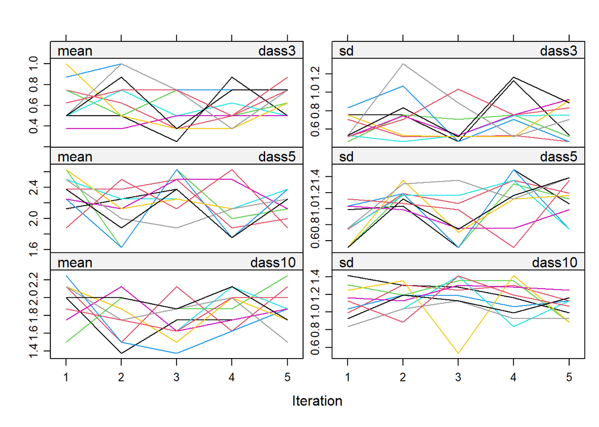

```r
plot(imp)
```

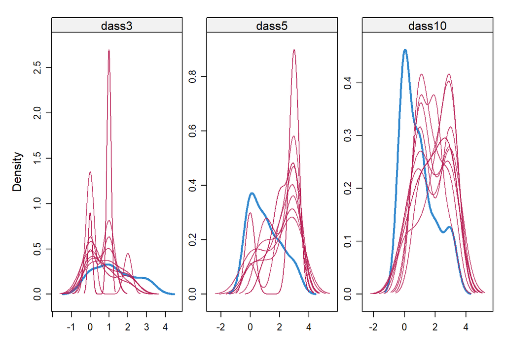

```r
densityplot(imp)
```

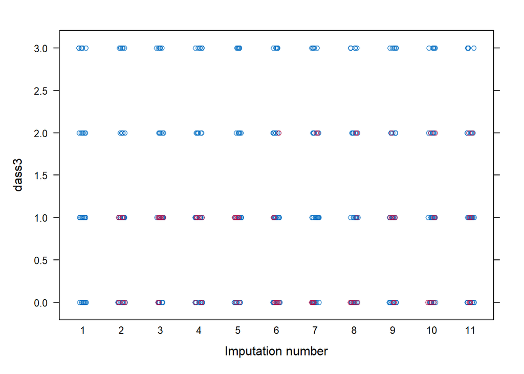

```r
stripplot(imp, dass3 ~ .imp)
```

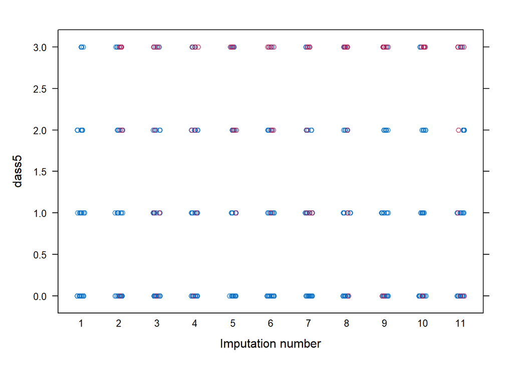

```r
stripplot(imp, dass5 ~ .imp)
```

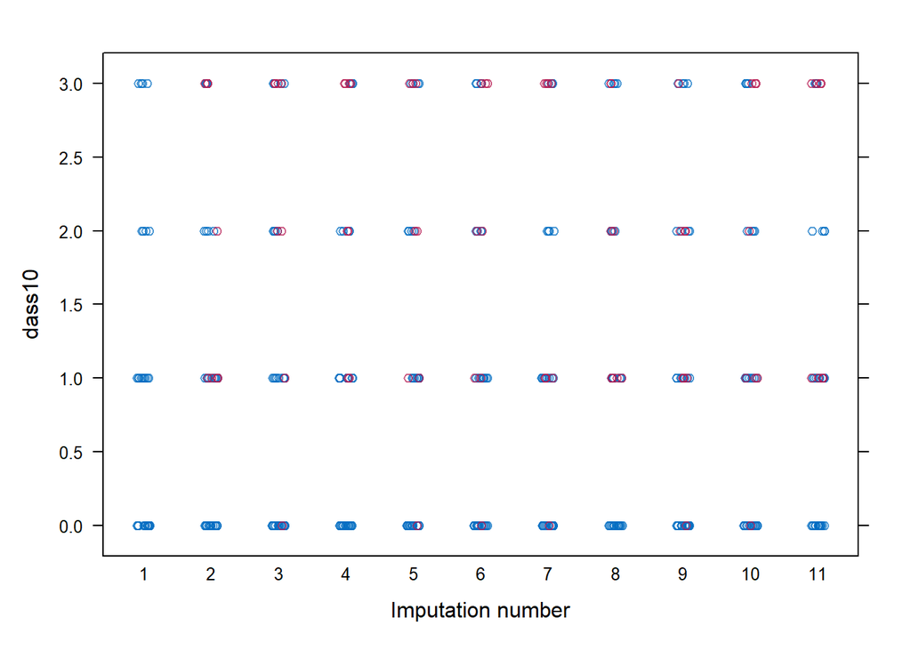

```r
stripplot(imp, dass10 ~ .imp)
```

## Getting summary statistics from MICE.

This is an area of mice which I find to be rather un-user friendly and unintuitive. But it is possible! Getting there just requires some tweaks of regression models by using no covariates (except the intercept). The `estimate` provides an estimation of the population mean, whilst the std.error is reported as well… unfortunatley we need to take some maths to convert from our standard error to out standard deviation. But the code is included here.

```r
depression_mean <- with(imp, lm(I(dass3 + dass5 + dass10 + dass16 + dass17 + dass21)~1))
summary(pool(depression_mean))
```

```
##          term estimate std.error statistic       df      p.value
## 1 (Intercept)      6.5 0.8825589  7.364947 37.07681 9.188021e-09
```

```r
# formula for converting st.error to sd
## std.error * square.root of population size
sd <- .882 * 6.325
sd
```

```
## [1] 5.57865
```

```r
imp %>% mice::complete("long") %>%
  select(dass3, dass5 , dass10 , dass16 , dass17 , dass21, eventsscore,  SOsupport) %>%
  mutate(Depression_subscale = (dass3 + dass5 + dass10 + dass16 + dass17 + dass21)) %>%
  select(Depression_subscale, eventsscore,  SOsupport) %>%
  summarise_all(list(~mean(.), ~sd(.), ~median(.)))
```

```
##   Depression_subscale_mean eventsscore_mean SOsupport_mean
## 1                      6.5              3.8           22.7
##   Depression_subscale_sd eventsscore_sd SOsupport_sd Depression_subscale_median
## 1                5.51371       2.229895      5.80899                          5
##   eventsscore_median SOsupport_median
## 1                3.5             24.5
```

And to compare with our original data and row wise imputation:

```r
summary(original$Depresion_subscale)
```

```
##    Min. 1st Qu.  Median    Mean 3rd Qu.    Max.
##   0.000   1.750   5.000   6.325  10.000  18.000
```

```r
sd(original$Depresion_subscale)
```

```
## [1] 5.534913
```

```r
summary(MAR_rowwise_mean_imp$Depresion_subscale)
```

```
##    Min. 1st Qu.  Median    Mean 3rd Qu.    Max.
##   0.000   1.800   4.800   6.418  10.125  18.000
```

```r
sd(MAR_rowwise_mean_imp$Depresion_subscale)
```

```
## [1] 5.542881
```

As for medians and quartile ranges, we need to use a quantile regression with our variable of choice - and no covariates. The quantile regression is performed using the `rq()` function from the `quantreg` package.

```r
library(quantreg)
#fit quantile regression to each imputed dataset
depression_med <- with(imp, rq(I(dass3 + dass5 + dass10 + dass16 + dass17 + dass21)~1))
```

From here we are forced into more awkwardness, as the `pool` function of mice does not work with the `rq` function. Instead we have to manually collect the results across the imputed datasets and pool them manually so that we can conform with Rubin’s rules.

```r
#extract estimates and variances

## set m to match m in mice
m <- 10

ests <- array(0, dim=m)
vars <- array(0, dim=m)
for (i in 1:m) {
  ests[i] <- summary.rq(depression_med$analyses[[i]],covariance=TRUE)$coefficients[1,1]
  vars[i] <- summary.rq(depression_med$analyses[[i]],covariance=TRUE)$coefficients[1,2]^2
}
#now apply Rubin's rules using pool.scalar
med_rubin <- pool.scalar(Q=ests, U=vars, n=dim(MAR_lifeevents[1]))
```

From here we can extract our median and standard error again:

```r
#median point estimate
med_rubin$qbar
```

```
## [1] 5
```

```r
#median standard error
med_rubin$t^0.5
```

```
## [1] 1.477799
```

And to compare with our original data and row wise imputation:

```r
summary(original$Depresion_subscale)
```

```
##    Min. 1st Qu.  Median    Mean 3rd Qu.    Max.
##   0.000   1.750   5.000   6.325  10.000  18.000
```

```r
summary(MAR_rowwise_mean_imp$Depresion_subscale)
```

```
##    Min. 1st Qu.  Median    Mean 3rd Qu.    Max.
##   0.000   1.800   4.800   6.418  10.125  18.000
```

### Cronbach Alpha and Mice

But what about checking to see how our cronbach alpha values are behaving under mice? This is more complicated, uses the `pool.scalar()` function, and requires some heavy coding (…and some help from the internet).

https://stackoverflow.com/questions/70816175/how-do-i-calculate-cronbachs-alpha-on-multiply-imputed-data

```r
# Step 2 - extract completed data in long format
implong <- complete(imp, 'long')

implong_subscale <- implong %>% select(.imp, dass3, dass5, dass10, dass16, dass17, dass21) # make sure to include ".imp", as it is needed for functions below to work. Also, add the subscales items you wish to calculate alpha for here.


#Step 2 - create cronbach alpha function for pooled data

cronbach_fun <- function(list_compl_data, boot = TRUE, B = 1e4, ci = FALSE) {
  n <- nrow(list_compl_data); p <- ncol(list_compl_data)
  total_variance <- var(rowSums(list_compl_data))
  item_variance <- sum(apply(list_compl_data, 2, sd)^2)
  alpha <- (p/(p - 1)) * (1 - (item_variance/total_variance))
  out <- list(alpha = alpha)
  boot_alpha <- numeric(B)
  if (boot) {
    for (i in seq_len(B)) {
      boot_dat <- list_compl_data[sample(seq_len(n), replace = TRUE), ]
      total_variance <- var(rowSums(boot_dat))
      item_variance <- sum(apply(boot_dat, 2, sd)^2)
      boot_alpha[i] <- (p/(p - 1)) * (1 - (item_variance/total_variance))
    }
    out$var <- var(boot_alpha)
  }
  if (ci){
    out$ci <- quantile(boot_alpha, c(.025,.975))
  }
  return(out)
}
```

The created `cronbach_fun()` has been designed to take on the following arguments:

The function cronbach_fun() takes the following arguments:

- list_compl_data: a character string specifying the list of completed data from a mids object.
- boot: a logical indicating whether a non-parametrical bootstrap should be conducted.
- B: an integer specifying the number of bootstrap samples to be taken.
- ci: a logical indicating whether a confidence interval around alpha should be estimated.

From here, its time to pool our estimates of the cronbach, using some more coding, and the `pool.scalar()` function used to ensure we do not violate the Rubin’s rules.

```r
m <- length(unique(implong_subscale$.imp)) # Set dataset inside `(unique(...)) to the dataset used for calculating cronbach alpha

boot_alpha <- rep(list(NA), m)
for (i in seq_len(m)) {
  set.seed(i) # fix random number generator
  sub <- implong_subscale[implong_subscale$.imp == i, -c(1,2)]
  boot_alpha[[i]] <- cronbach_fun(sub)
}

# obtain Q and U (see ?pool.scalar)
Q <- sapply(boot_alpha, function(x) x$alpha)
U <- sapply(boot_alpha, function(x) x$var)


# pooled estimates
pool_estimates <- function(x) {
  out <- c(
    alpha = x$qbar,
    lwr = x$qbar - qt(0.975, x$df) * sqrt(x$t),
    upr = x$qbar + qt(0.975, x$df) * sqrt(x$t)
  )
  return(out)
}

# Pooled estimate of alpha (95% CI)
 pool_estimates(pool.scalar(Q, U ))
```

```
##     alpha       lwr       upr
## 0.9331007 0.8961521 0.9700494
```

To compare this with the original of the row mean imputation method of Cronbach’s Alpha:

```r
ltm::cronbach.alpha(original_alpha_depression)
```

```
##
## Cronbach's alpha for the 'original_alpha_depression' data-set
##
## Items: 6
## Sample units: 40
## alpha: 0.953
```

```r
ltm::cronbach.alpha(alpha_depression)
```

```
##
## Cronbach's alpha for the 'alpha_depression' data-set
##
## Items: 6
## Sample units: 40
## alpha: 0.956
```

## Bonus Section

Disclaimer - In the creation of the materials of this workshop, I have come to appreciate that whilst MICE is incredibly powerful, it is also incredibly complicated, and requires many technical decisions. Meanwhile, FIML appears to be comparable in its ability to perform imputation. Thus, I have included a quick demo.

### FIML

Here is a quick demo of how we might use FIML for psychometric regression based analyses. We specify `missing = "fiml"` which then uses fiml to account for the missing data. In addition, we include: `fixed.x = F`. FIML works by estimating the relationships of the variables with each other and requires estimating the means and variances of the variables. If `fixed.x = T` (the default), then the variances and covariances are fixed and are based on the existing sample values and are not estimated.

```r
library(lavaan)
nomiss <- sem('Depresion_subscale ~ eventsscore + SOsupport', data = original)

summary(nomiss)
```

```
## lavaan 0.6.16 ended normally after 1 iteration
##
##   Estimator                                         ML
##   Optimization method                           NLMINB
##   Number of model parameters                         3
##
##   Number of observations                            40
##
## Model Test User Model:
##
##   Test statistic                                 0.000
##   Degrees of freedom                                 0
##
## Parameter Estimates:
##
##   Standard errors                             Standard
##   Information                                 Expected
##   Information saturated (h1) model          Structured
##
## Regressions:
##                        Estimate  Std.Err  z-value  P(>|z|)
##   Depresion_subscale ~
##     eventsscore           0.831    0.339    2.454    0.014
##     SOsupport            -0.309    0.130   -2.374    0.018
##
## Variances:
##                    Estimate  Std.Err  z-value  P(>|z|)
##    .Depresin_sbscl   22.334    4.994    4.472    0.000
```

```r
mod_meas <- '
Dep =~ dass3 + dass5 + dass10 + dass16 + dass17 + dass21
Dep ~ eventsscore + SOsupport
'

wmiss <- sem(mod_meas, data = MAR, missing = 'fiml', fixed.x = F)

summary(wmiss)
```

```
## lavaan 0.6.16 ended normally after 47 iterations
##
##   Estimator                                         ML
##   Optimization method                           NLMINB
##   Number of model parameters                        25
##
##   Number of observations                            40
##   Number of missing patterns                         5
##
## Model Test User Model:
##
##   Test statistic                                18.058
##   Degrees of freedom                                19
##   P-value (Chi-square)                           0.519
##
## Parameter Estimates:
##
##   Standard errors                             Standard
##   Information                                 Observed
##   Observed information based on                Hessian
##
## Latent Variables:
##                    Estimate  Std.Err  z-value  P(>|z|)
##   Dep =~
##     dass3             1.000
##     dass5             0.940    0.177    5.303    0.000
##     dass10            1.107    0.117    9.498    0.000
##     dass16            1.039    0.097   10.677    0.000
##     dass17            0.768    0.101    7.602    0.000
##     dass21            0.824    0.101    8.147    0.000
##
## Regressions:
##                    Estimate  Std.Err  z-value  P(>|z|)
##   Dep ~
##     eventsscore       0.136    0.063    2.178    0.029
##     SOsupport        -0.055    0.024   -2.287    0.022
##
## Covariances:
##                    Estimate  Std.Err  z-value  P(>|z|)
##   eventsscore ~~
```

[output cut: 10 more lines]

```
##     eventsscore       3.800    0.352   10.791    0.000
##     SOsupport        22.700    0.917   24.746    0.000
##    .Dep               0.000
##
## Variances:
##                    Estimate  Std.Err  z-value  P(>|z|)
##    .dass3             0.157    0.051    3.065    0.002
##    .dass5             0.512    0.137    3.737    0.000
##    .dass10            0.137    0.051    2.711    0.007
##    .dass16            0.117    0.040    2.900    0.004
##    .dass17            0.248    0.061    4.051    0.000
##    .dass21            0.223    0.057    3.900    0.000
##    .Dep               0.699    0.188    3.727    0.000
##     eventsscore       4.960    1.109    4.472    0.000
##     SOsupport        33.660    7.527    4.472    0.000
```

## References

Rubin, D.B. (1987). Multiple Imputation for Nonresponse in Surveys. New York: John Wiley and Sons.